# **Interpretation of the Plots**

## **Weekly Resampling for Smoother Trend Analysis:**

The weekly average resampling smooths out the daily price volatility, allowing us to identify general trends more easily. This technique helps in visualizing price cycles and long-term movements.

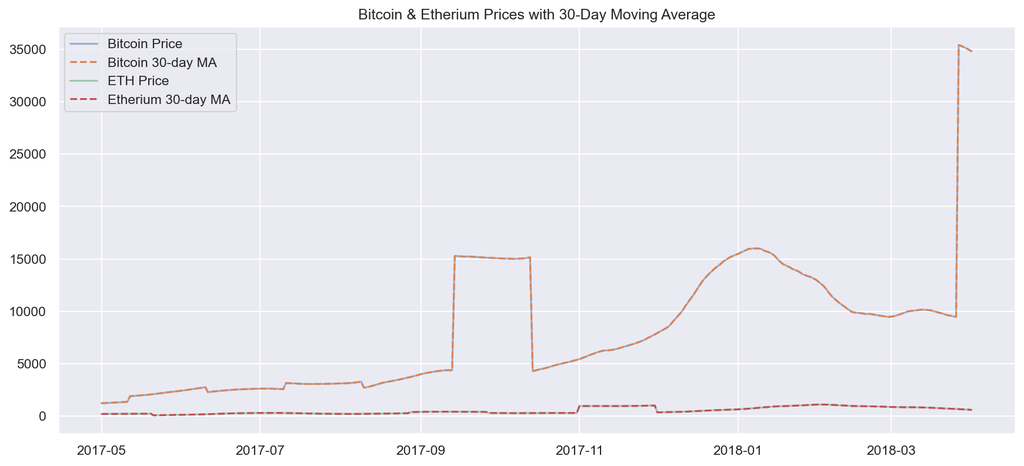

```python
# Moving average
df_bit['Bitcoin'] = df_bit['Bitcoin'].rolling(window=30).mean()
df_bit['Ether'] = df_bit['Ether'].rolling(window=30).mean()

plt.figure(figsize=(14, 6))
plt.plot(df_bit.index, df_bit['Bitcoin'], alpha=0.5, label='Bitcoin Price')
plt.plot(df_bit.index, df_bit['Bitcoin'], label='Bitcoin 30-day MA', linestyle='--')
plt.plot(df_bit.index, df_bit['Ether'], alpha=0.5, label='ETH Price')
plt.plot(df_bit.index, df_bit['Ether'], label='Etherium 30-day MA', linestyle='--')
plt.legend()
plt.title('Bitcoin & Etherium Prices with 30-Day Moving Average')
plt.show()
```

## **30-Day Moving Average for Trend Detection:**

Applying a rolling 30-day moving average to Bitcoin and Ethereum prices reduces short-term fluctuations and highlights long-term trends. The smoothed-out price trends make it easier to identify bullish (rising) and bearish (falling) market trends.

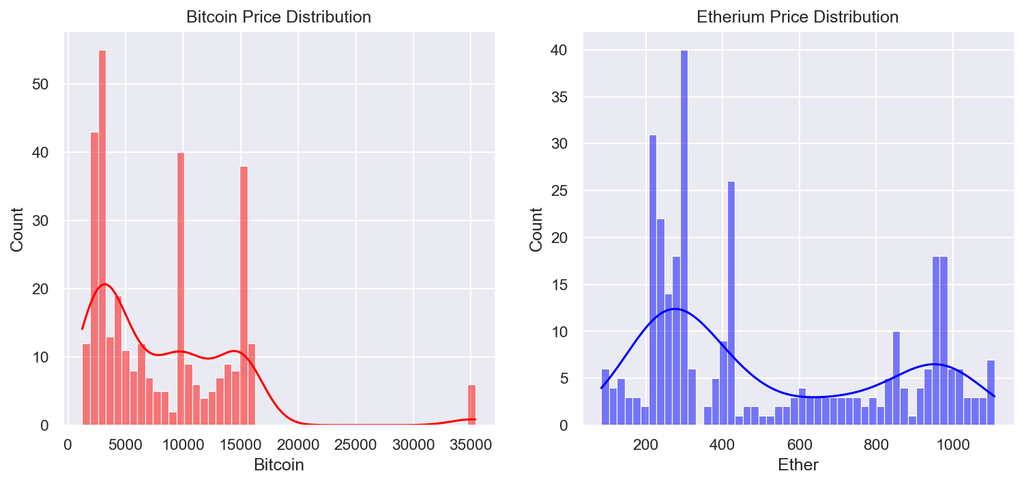

```python
# Histogram
fig, ax = plt.subplots(1, 2, figsize=(12, 5))
sns.histplot(df_bit['Bitcoin'], bins=50, kde=True, ax=ax[0], color='red')
sns.histplot(df_bit['Ether'], bins=50, kde=True, ax=ax[1], color='blue')
ax[0].set_title('Bitcoin Price Distribution')
ax[1].set_title('Etherium Price Distribution')
plt.show()
```